# Choice Based Conjoint MNL model: Gym Subscriptions Case Study

Among the public places hardest hit by the lockdown to try to bring down the rate of coronavirus, there are certainly gyms, which have been closed since October and will probably be the last business to reopen. In order to understand which are the factors on which one can invest to relaunch the sector, survey participants are asked to choose one of different subscription profiles. The various types of subscription include:

- subscription duration (monthly / three-months / yearly)
- type of activities (only fitness room / fitness room plus courses)
- time slots in which the costumer can access the structure (7-12 / 18-23 / all day)
- type of training schedule (standard / personalized) - additional services (not included / access to the wellness center / physiotherapy consultancy)
- corresponding price per month (40 euros / 60 euros / 80 euros)

The aim of the data analysis is to assess the relationship between the choice and the product attributes. To do this we use a discrete choice model, such as the multinomial logit regression.

```r
palestra <- read.csv("C:/Users/tamar/OneDrive/Desktop/DS-2 anno/lab of costumer/palestra.csv", sep=";")
dim(palestra) #24000 x 10
str(palestra)
```

```r
head(palestra)
```

|  | resp.id | ques | alt | abbonamento | attivita | orario | tabella | servizi | prezzo | choice |
| --- | --- | --- | --- | --- | --- | --- | --- | --- | --- | --- |
| 1 | 1 | 1 | 1 | mensile | attrezzi+corsi | 7_12 | personalizzata | centro.benessere | 40 | 0 |
| 2 | 1 | 1 | 2 | mensile | attrezzi+corsi | 18_23 | standard | consulenza.fisioterapica | 40 | 1 |
| 3 | 1 | 1 | 3 | annuale | attrezzi+corsi | 18_23 | standard | centro.benessere | 80 | 0 |
| 4 | 1 | 1 | 4 | mensile | attrezzi | 18_23 | personalizzata | centro.benessere | 80 | 0 |
| 5 | 1 | 2 | 1 | annuale | attrezzi | allDay | personalizzata | centro.benessere | 80 | 0 |
| 6 | 1 | 2 | 2 | mensile | attrezzi | allDay | personalizzata | non.inclusi | 80 | 0 |

Data are in long format and each respondent has to choose between 4 alternative.

```r
options(max.print=100)
sapply(palestra,table) #distribution of each variable
```

```
$resp.id

  1   2   3   4   5   6   7   8   9  10  11  12  13  14  15  16
 80  80  80  80  80  80  80  80  80  80  80  80  80  80  80  80
 17  18  19  20  21  22  23  24  25  26  27  28  29  30  31  32
 80  80  80  80  80  80  80  80  80  80  80  80  80  80  80  80
 33  34  35  36  37  38  39  40  41  42  43  44  45  46  47  48
 80  80  80  80  80  80  80  80  80  80  80  80  80  80  80  80
 49  50  51  52  53  54  55  56  57  58  59  60  61  62  63  64
 80  80  80  80  80  80  80  80  80  80  80  80  80  80  80  80
 65  66  67  68  69  70  71  72  73  74  75  76  77  78  79  80
 80  80  80  80  80  80  80  80  80  80  80  80  80  80  80  80
 81  82  83  84  85  86  87  88  89  90  91  92  93  94  95  96
 80  80  80  80  80  80  80  80  80  80  80  80  80  80  80  80
 97  98  99 100
 80  80  80  80
 [ reached getOption("max.print") -- omitted 200 entries ]

$ques

  1   2   3   4   5   6   7   8   9  10  11  12  13  14  15  16
  4   4   4   4   4   4   4   4   4   4   4   4   4   4   4   4
 17  18  19  20  21  22  23  24  25  26  27  28  29  30  31  32
  4   4   4   4   4   4   4   4   4   4   4   4   4   4   4   4
 33  34  35  36  37  38  39  40  41  42  43  44  45  46  47  48
  4   4   4   4   4   4   4   4   4   4   4   4   4   4   4   4
 49  50  51  52  53  54  55  56  57  58  59  60  61  62  63  64
  4   4   4   4   4   4   4   4   4   4   4   4   4   4   4   4
 65  66  67  68  69  70  71  72  73  74  75  76  77  78  79  80
  4   4   4   4   4   4   4   4   4   4   4   4   4   4   4   4
 81  82  83  84  85  86  87  88  89  90  91  92  93  94  95  96
  4   4   4   4   4   4   4   4   4   4   4   4   4   4   4   4
 97  98  99 100
  4   4   4   4
 [ reached getOption("max.print") -- omitted 5900 entries ]

$alt

   1    2    3    4
6000 6000 6000 6000
```

[output cut: 22 more lines]

```

        centro.benessere consulenza.fisioterapica
                    8050                     8034
             non.inclusi
                    7916

$prezzo

  40   60   80
7989 7996 8015

$choice

    0     1
18000  6000
```

We can see that each respondent has look at 80 product profiles. Each level of each attribute is properly represented and well balanced, as all levels have the same frequency. There are no respondent level variables.  
See some descriptive statistics:

```r
summary(palestra)
```

```
    resp.id            ques           alt
 Min.   :  1.00   Min.   :   1   Min.   :1.00
 1st Qu.: 75.75   1st Qu.:1501   1st Qu.:1.75
 Median :150.50   Median :3000   Median :2.50
 Mean   :150.50   Mean   :3000   Mean   :2.50
 3rd Qu.:225.25   3rd Qu.:4500   3rd Qu.:3.25
 Max.   :300.00   Max.   :6000   Max.   :4.00
 abbonamento          attivita            orario
 Length:24000       Length:24000       Length:24000
 Class :character   Class :character   Class :character
 Mode  :character   Mode  :character   Mode  :character



   tabella            servizi              prezzo
 Length:24000       Length:24000       Min.   :40.00
 Class :character   Class :character   1st Qu.:40.00
 Mode  :character   Mode  :character   Median :60.00
                                       Mean   :60.02
                                       3rd Qu.:80.00
                                       Max.   :80.00
     choice
 Min.   :0.00
 1st Qu.:0.00
 Median :0.00
 Mean   :0.25
 3rd Qu.:0.25
 Max.   :1.00
```

```r
xtabs(choice ~ abbonamento, data=palestra) #On average consumers prefer annual subscription
```

```
abbonamento
    annuale     mensile trimestrale
       3006        1688        1306
```

```r
xtabs(choice ~ attivita, data=palestra) #On average consumers prefer fitness room plus courses instead of the only fitness room
```

```
attivita
      attrezzi attrezzi+corsi
          2536           3464
```

```r
xtabs(choice ~ orario, data=palestra)#On average consumers prefer the evening schedule
```

```
orario
 18_23   7_12 allDay
  3242   1962    796
```

```r
xtabs(choice ~ tabella, data=palestra) #On average consumers prefer the standard training schedule
```

```
tabella
personalizzata       standard
          2719           3281
```

```r
xtabs(choice ~ servizi, data=palestra) #On average consumers prefer physiotherapy consultancy as an additional service.
```

```
servizi
        centro.benessere consulenza.fisioterapica
                    1031                     2771
             non.inclusi
                    2198
```

```r
xtabs(choice ~ prezzo, data=palestra) #On average consumers prefer the lower price (40 euros/month)
```

```
prezzo
  40   60   80
2312 1897 1791
```

## MULTINOMIAL LOGIT MODEL

Since customers have to choose between 4 alternative, we are in the context of a multilevel logit model.  
First of all we have to recode the variable as qualitative, also by changing the categories order of some of them in order to have a specific reference level.

```r
palestra$abbonamento <- factor(palestra$abbonamento, levels = c("mensile","trimestrale","annuale"))
palestra$attivita <- as.factor(palestra$attivita)
palestra$orario<-factor(palestra$orario, levels = c("allDay", "18_23","7_12"))
palestra$tabella<- factor(palestra$tabella, levels=c("standard","personalizzata" ))
palestra$servizi<-factor(palestra$servizi, levels=c("consulenza.fisioterapica",
  "centro.benessere", "non.inclusi" ))
palestra$prezzo<-as.factor(palestra$prezzo)
```

Then organize the data in long format in the properly way for the mlogit function:

```r
palestra_mlogit <- dfidx(palestra, idx = list(c("ques", "resp.id"), "alt"), drop.index=F,
                        levels=c("1", "2", "3", "4"))
```

Now we can fit the MNL model:

```r
m1 <- mlogit(choice ~ abbonamento +attivita + orario+ tabella + servizi + prezzo, data = palestra_mlogit)
summary(m1)
```

```
Call:
mlogit(formula = choice ~ abbonamento + attivita + orario + tabella +
    servizi + prezzo, data = palestra_mlogit, method = "nr")

Frequencies of alternatives:choice
      1       2       3       4
0.25633 0.25500 0.24150 0.24717

nr method
5 iterations, 0h:0m:1s
g'(-H)^-1g = 1.82E-07
gradient close to zero

Coefficients :
                         Estimate Std. Error  z-value Pr(>|z|)
(Intercept):2           -0.024577   0.043446  -0.5657   0.5716
(Intercept):3           -0.066762   0.043885  -1.5213   0.1282
(Intercept):4           -0.025792   0.043810  -0.5887   0.5560
abbonamentotrimestrale  -0.407393   0.047441  -8.5874   <2e-16
abbonamentoannuale       1.146834   0.043888  26.1312   <2e-16
attivitaattrezzi+corsi   0.623608   0.036542  17.0654   <2e-16
orario18_23              2.359177   0.054307  43.4414   <2e-16
orario7_12               1.397186   0.052572  26.5765   <2e-16
tabellapersonalizzata   -0.333451   0.035824  -9.3080   <2e-16
servizicentro.benessere -1.756346   0.050374 -34.8662   <2e-16
servizinon.inclusi      -0.438293   0.041126 -10.6572   <2e-16
prezzo60                -0.379502   0.043324  -8.7597   <2e-16
prezzo80                -0.507472   0.044098 -11.5080   <2e-16

(Intercept):2
(Intercept):3
(Intercept):4
abbonamentotrimestrale  ***
abbonamentoannuale      ***
attivitaattrezzi+corsi  ***
orario18_23             ***
orario7_12              ***
tabellapersonalizzata   ***
servizicentro.benessere ***
servizinon.inclusi      ***
prezzo60                ***
prezzo80                ***
---
Signif. codes:  0 ‘***’ 0.001 ‘**’ 0.01 ‘*’ 0.05 ‘.’ 0.1 ‘ ’ 1

Log-Likelihood: -5676
McFadden R^2:  0.31747
Likelihood ratio test : chisq = 5280.1 (p.value = < 2.22e-16)
```

Considering that estimated coefficients are on the logit scale and tend to range mainly between -2 and 2, we can conclude that on average:

- customers strongly prefer the yearly subscription compared to the monthly one, on the contrary the three-months subscription is slightly less preferred than the monthly one
- customers prefer that in the subscription is included the possibility of attending both fitness room and the courses instead of the only fitness room
- customers strongly prefer a cheaper subscription that allows them to enter the gym at a specific time slot than the more expensive subscription that allows them to enter at any time. The preferred time slot is 18-23
- customers prefer the standard training schedule
- customers are strongly not interested having the in wellness center as an additional service, while the physiotherapy consultancy is preferred over having the additional services not included.
- customers prefers the lower price

Concerning the alternative specific constants, they are are not significant and indeed here we are not expected a respondent chooses a subscription option because it is positioned in a certain way. We can check if this intuition is correct by fitting a nested smaller model without intercept parameters and then by comparing it with the the larger model with intercepts through a likelihood ratio test.

```r
m2 <- mlogit(choice ~ abbonamento +attivita + orario+ tabella + servizi + prezzo| -1, data = palestra_mlogit)
lrtest(m2,m1) #comparison between models
```

```
Likelihood ratio test

Model 1: choice ~ abbonamento + attivita + orario + tabella + servizi +
    prezzo | -1
Model 2: choice ~ abbonamento + attivita + orario + tabella + servizi +
    prezzo
  #Df  LogLik Df  Chisq Pr(>Chisq)
1  10 -5677.1
2  13 -5676.0  3 2.3767      0.498
```

The comparison leads to a large p-value of 0.498. Therefore we can conclude that the two models are not significantly different in terms of goodness of fit and they explain the data equally well. As consequences, alternative specific constants are not necessary to adequately model the data.

### Compute the willingness-to-pay

The likelihood ratio test can be also useful to decide if the price variable must be included as quantitative predictor instead of being qualitative. Therefore we now fit the model without intercept parameters and with *prezzo* as a quantitative variable in order to compare it with the restricted model with *prezzo* as qualitative.

```r
m3 <- mlogit(choice ~ abbonamento +attivita + orario+ tabella + servizi
                      + as.numeric(as.character(prezzo)) | -1, data = palestra_mlogit)
lrtest(m3, m2) #comparison between models
```

```
Likelihood ratio test

Model 1: choice ~ abbonamento + attivita + orario + tabella + servizi +
    as.numeric(as.character(prezzo)) | -1
Model 2: choice ~ abbonamento + attivita + orario + tabella + servizi +
    prezzo | -1
  #Df  LogLik Df Chisq Pr(>Chisq)
1   9 -5682.5
2  10 -5677.1  1 10.79   0.001021 **
---
Signif. codes:  0 ‘***’ 0.001 ‘**’ 0.01 ‘*’ 0.05 ‘.’ 0.1 ‘ ’ 1
```

This comparison leads instead to a p value of 0.001. It means that this new specification significantly reduce the goodness of fit and it is better to keep price variable as qualitative.  
Nevertheless 0.001 may be considered a borderline result in terms of statistical significance and choosing the highest significance level, we might consider the model with quantitative price variable and try to compute the willingness-to-pay, since interpreting the measures of part-worths is quite difficult.For example for the personalized schedule level we can compute the following quantity expressed in euros:

```r
coef(m3)["tabellapersonalizzata"]/(coef(m3)["as.numeric(as.character(prezzo))"])
```

```
tabellapersonalizzata
             25.99332
```

The interpretation is that 26 euros is the price at which customers tend to become indifferent between the two schedule options (standard or personalized).

### Simulate Preference Shares

Together with willingness-to-pay measures, another useful approach to assess the role of subscription attributes consists on using the model to obtain preference share predictions.  
First of all we have to define the “predict.mnl” function.

```r
predict.mnl <- function(model, data) {

  data.model <- model.matrix(update(model$formula, 0 ~ .), data = data)[,-1]
  logitUtility <- data.model%*%model$coef
  share <- exp(logitUtility)/sum(exp(logitUtility))
  cbind(share, data)
}
```

And then we choose a reasonable subset where the first row indicates our planned design and the others rows indicate realistic designs offered by competitors:

```r
new_data <- allDesign[c(12, 85, 274,140,185,132), ]
new_data
```

|  | abbonamento | attivita | orario | tabella | servizi | prezzo |
| --- | --- | --- | --- | --- | --- | --- |
| 12 | annuale | attrezzi+corsi | 18_23 | standard | consulenza.fisioterapica | 40 |
| 85 | mensile | attrezzi | 7_12 | standard | non.inclusi | 40 |
| 274 | mensile | attrezzi+corsi | allDay | personalizzata | centro.benessere | 80 |
| 140 | trimestrale | attrezzi | 7_12 | personalizzata | consulenza.fisioterapica | 60 |
| 185 | trimestrale | attrezzi+corsi | allDay | standard | non.inclusi | 60 |
| 132 | annuale | attrezzi+corsi | allDay | personalizzata | consulenza.fisioterapica | 60 |

Now we can predict the preference shares:

```r
predict.mnl(m2, new_data)
```

|  | share | abbonamento | attivita | orario | tabella | servizi | prezzo |
| --- | --- | --- | --- | --- | --- | --- | --- |
| 12 | 0.892295710 | annuale | attrezzi+corsi | 18_23 | standard | consulenza.fisioterapica | 40 |
| 85 | 0.037509982 | mensile | attrezzi | 7_12 | standard | non.inclusi | 40 |
| 274 | 0.001994762 | mensile | attrezzi+corsi | allDay | personalizzata | centro.benessere | 80 |
| 140 | 0.018952457 | trimestrale | attrezzi | 7_12 | personalizzata | consulenza.fisioterapica | 60 |
| 185 | 0.007878714 | trimestrale | attrezzi+corsi | allDay | standard | non.inclusi | 60 |
| 132 | 0.041368375 | annuale | attrezzi+corsi | allDay | personalizzata | consulenza.fisioterapica | 60 |

```r
NA
```

We expect consumers to choose our product design basically 89% of times.  
It useful to get not only the point estimates but also the bootstrap confidence intervals for the preference shares. Indeed predictions are not reliable if the level of accertainty is not declared.

```r
source("BootCI.predict.mnl.R") #load the function
library(parallel)
BootCI.predict.mnl(m2  , new_data, nsim = 500, conflevel = 0.95) #use the default values
```

|  | share | 2.5% | 97.5% | abbonamento | attivita | orario | tabella | servizi | prezzo |
| --- | --- | --- | --- | --- | --- | --- | --- | --- | --- |
| 12 | 0.892295710 | 0.878593094 | 0.906149668 | annuale | attrezzi+corsi | 18_23 | standard | consulenza.fisioterapica | 40 |
| 85 | 0.037509982 | 0.031590287 | 0.043577480 | mensile | attrezzi | 7_12 | standard | non.inclusi | 40 |
| 274 | 0.001994762 | 0.001601032 | 0.002483956 | mensile | attrezzi+corsi | allDay | personalizzata | centro.benessere | 80 |
| 140 | 0.018952457 | 0.015707875 | 0.022436234 | trimestrale | attrezzi | 7_12 | personalizzata | consulenza.fisioterapica | 60 |
| 185 | 0.007878714 | 0.006463266 | 0.009512343 | trimestrale | attrezzi+corsi | allDay | standard | non.inclusi | 60 |
| 132 | 0.041368375 | 0.035228241 | 0.047236652 | annuale | attrezzi+corsi | allDay | personalizzata | consulenza.fisioterapica | 60 |

```r
NA
```

### Sensitivity chart

It can be useful to plot the expected changes in preference shares by plotting the sensitivity chart for our planned subscription design with: yearly duration, fitness room plus courses, 18-23 time slot,standard training schedule, physiotherapy consultancy included for a prince of 40/month.

```r
sensitivity.mnl <- function(model, attrib, base.data, competitor.data) {

  data <- rbind(base.data, competitor.data)
  base.share <- predict.mnl(model, data)[1,1]
  share <- NULL
  for (a in seq_along(attrib)) {
    for (i in attrib[[a]]) {
      data[1,] <- base.data
      data[1,a] <- i
      share <- c(share, predict.mnl(model, data)[1,1])
    }
  }
  data.frame(level=unlist(attrib), share=share, increase=share-base.share)
}
```

```r
base.data <- new_data[1,]
competitor.data <- new_data[-1,]
(tradeoff <- sensitivity.mnl(m2, attributes, base.data, competitor.data)) #importance of the attributes (preference share)
tradeoff$level
```

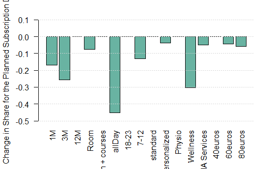

```r
barplot(tradeoff$increase, horiz=F, names.arg=c("1M","3M", "12M","Room", "Room + courses","allDay","18-23","7-12", "standard", "personalized", "Physio","Wellness","NA Services", "40euros", "60euros", "80euros"),
        las=2 ,
        col="#69b3a2",
        ylab="Change in Share for the Planned Subscription Design",

        ylim=c(-0.5,0.1))
grid(nx=NA, ny=NULL)
```

We can see that each change in the attribute levels of the planned design leads to a preference share decrease. In particular the worst changes would be:

- In the time slot attribute: from 18-23 level to All Day level.In this case the preference share decreases by almost 0.5
- In the additional services attribute: from physiotherapy consultancy to access to wellness center. In this case the preference share decreases by 0.3
- In the duration attribute: from yearly duration level to 3-months level. In this case the preference share decreases by almost 0.3

## MIXED MULTINOMIAL LOGIT MODEL

```r
rpar <- rep("n", length=length(m2$coef))
names(rpar) <- names(m2$coef)
```

We pass this vector to mlogit as the rpar parameter, which stands for random parameters. In addition, we tell mlogit that we have multiple choice observations for each respondent (panel=TRUE) and that we do not want to allow the random parameters to be correlated with each other (correlation=FALSE)

```r
m2_mixed <- mlogit(choice ~ abbonamento +attivita + orario+ tabella + servizi + prezzo| -1, data = palestra_mlogit,
                  panel=TRUE, rpar = rpar, correlation = FALSE)
```

```r
summary(m2_mixed)
```

```
Call:
mlogit(formula = choice ~ abbonamento + attivita + orario + tabella +
    servizi + prezzo | -1, data = palestra_mlogit, rpar = rpar,
    correlation = FALSE, panel = TRUE)

Frequencies of alternatives:choice
      1       2       3       4
0.25633 0.25500 0.24150 0.24717

bfgs method
21 iterations, 0h:0m:34s
g'(-H)^-1g = 6.99E-07
gradient close to zero

Coefficients :
                            Estimate Std. Error  z-value
abbonamentotrimestrale     -0.486017   0.054078  -8.9874
abbonamentoannuale          1.294231   0.049166  26.3237
attivitaattrezzi+corsi      0.727209   0.040848  17.8028
orario18_23                 2.715557   0.065606  41.3919
orario7_12                  1.568336   0.058431  26.8407
tabellapersonalizzata      -0.412262   0.040166 -10.2640
servizicentro.benessere    -2.050825   0.061225 -33.4967
servizinon.inclusi         -0.489532   0.045176 -10.8362
prezzo60                   -0.491440   0.048587 -10.1147
prezzo80                   -0.560255   0.048866 -11.4651
sd.abbonamentotrimestrale   0.542538   0.070624   7.6821
sd.abbonamentoannuale       0.223251   0.072308   3.0875
sd.attivitaattrezzi+corsi   0.326159   0.067601   4.8248
sd.orario18_23              0.798080   0.053542  14.9057
sd.orario7_12              -0.139912   0.076097  -1.8386
sd.tabellapersonalizzata    0.383228   0.062030   6.1781
sd.servizicentro.benessere  0.877216   0.066219  13.2472
sd.servizinon.inclusi       0.540150   0.064597   8.3618
sd.prezzo60                 0.693683   0.062119  11.1670
sd.prezzo80                 0.048385   0.087589   0.5524
                            Pr(>|z|)
abbonamentotrimestrale     < 2.2e-16 ***
abbonamentoannuale         < 2.2e-16 ***
attivitaattrezzi+corsi     < 2.2e-16 ***
```

[output cut: 30 more lines]

```
servizicentro.benessere -Inf -2.6424986 -2.0508253 -2.0508253
servizinon.inclusi      -Inf -0.8538577 -0.4895320 -0.4895320
prezzo60                -Inf -0.9593217 -0.4914399 -0.4914399
prezzo80                -Inf -0.5928898 -0.5602548 -0.5602548
                            3rd Qu. Max.
abbonamentotrimestrale  -0.12008080  Inf
abbonamentoannuale       1.44481199  Inf
attivitaattrezzi+corsi   0.94719982  Inf
orario18_23              3.25385331  Inf
orario7_12               1.66270557  Inf
tabellapersonalizzata   -0.15377895  Inf
servizicentro.benessere -1.45915192  Inf
servizinon.inclusi      -0.12520635  Inf
prezzo60                -0.02355802  Inf
prezzo80                -0.52761978  Inf
```

For each level attribute we estimate now two parameters instead of one: the estimated average coefficients and the estimated standard deviations, indicating the variability of coefficients across respondents. In general the higher the standard deviation the higher the heterogeneity. In particular we may have to consider the heterogeneity in the preference for:

- the yearly subscription over the three-months one: while consumers on average prefer the annual subscription, there is a non-negligible fraction of them which prefer the three-month one
- the physiotherapy consultancy as an additional service over having additional services not included
- the lower price over the one of 60 euro

The random effects do not show sign reversals in the quartiles distribution but we can check the visual summary of the distribution of the random effects and hence of the level of heterogeneity:

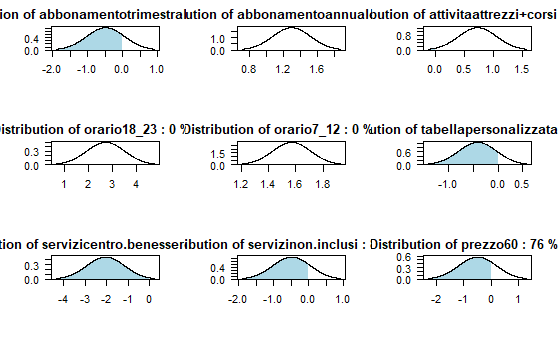

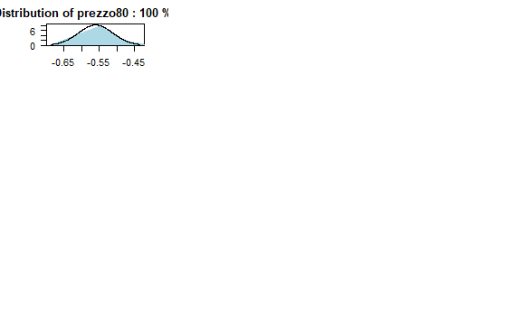

```r
plot(m2_mixed)
```

As the plot shows, there is a narrow market niche of customers who has a stronger preference for the three-months subscription with respect to average customers preference and there is also a narrow niche who has a stronger preference for having the additional services not included with respect to other customers.

### Mixed MLN Model with correlated random effects

The model above has covariances among random effects equal to zero, but with correlated random effect coefficients one can asses whether consumers who favor one attribute level also tend to favor another attribute level. So now we use the update function provided by mlogit to estimate the mixed MNL model with correlated random effects:

```r
m2_mixed2 <- update(m2_mixed, correlation = TRUE)
```

We can test the hypothesis that the random parameters are uncorrelated:

```r
waldtest(m2_mixed2, correlation = FALSE)
```

```
    Wald test

data:  uncorrelated random effects
chisq = 428.44, df = 45, p-value < 2.2e-16
```

The test clearly reject the hypothesis that the random parameters are uncorrelated.  
To get a better sense of the strength of the association among random coefficients, we extract the covariance matrix:

```r
as.data.frame(cov2cor(cov.mlogit(m2_mixed2)))
```

|  | abbonamentotrimestrale | abbonamentoannuale | attivitaattrezzi+corsi | orario18_23 | orario7_12 | tabellapersonalizzata | servizicentro.benessere | servizinon.inclusi | prezzo60 | prezzo80 |
| --- | --- | --- | --- | --- | --- | --- | --- | --- | --- | --- |
| abbonamentotrimestrale | 1.00000000 | -0.85069212 | 0.10521163 | 0.07520412 | 0.285746749 | 0.08982321 | 0.05561454 | 0.085062122 | -0.42532620 | -0.5202333 |
| abbonamentoannuale | -0.85069212 | 1.00000000 | 0.06319491 | -0.22695057 | -0.280254214 | 0.39590559 | -0.04087804 | -0.024087283 | 0.43108644 | 0.3393320 |
| attivitaattrezzi+corsi | 0.10521163 | 0.06319491 | 1.00000000 | 0.36497683 | 0.471215706 | 0.18106125 | -0.13085697 | -0.482562621 | 0.13685190 | -0.4447171 |
| orario18_23 | 0.07520412 | -0.22695057 | 0.36497683 | 1.00000000 | 0.927116089 | -0.15006850 | 0.08013375 | 0.056267312 | -0.11197571 | -0.1785393 |
| orario7_12 | 0.28574675 | -0.28025421 | 0.47121571 | 0.92711609 | 1.000000000 | 0.13539708 | 0.08849625 | 0.004870322 | -0.29445809 | -0.3803329 |
| tabellapersonalizzata | 0.08982321 | 0.39590559 | 0.18106125 | -0.15006850 | 0.135397078 | 1.00000000 | 0.16208895 | 0.115152887 | -0.05144348 | -0.2350627 |
| servizicentro.benessere | 0.05561454 | -0.04087804 | -0.13085697 | 0.08013375 | 0.088496254 | 0.16208895 | 1.00000000 | 0.675232982 | -0.15673491 | -0.3777922 |
| servizinon.inclusi | 0.08506212 | -0.02408728 | -0.48256262 | 0.05626731 | 0.004870322 | 0.11515289 | 0.67523298 | 1.000000000 | -0.14340785 | -0.1788344 |
| prezzo60 | -0.42532620 | 0.43108644 | 0.13685190 | -0.11197571 | -0.294458089 | -0.05144348 | -0.15673491 | -0.143407846 | 1.00000000 | 0.4746354 |
| prezzo80 | -0.52023335 | 0.33933200 | -0.44471712 | -0.17853934 | -0.380332873 | -0.23506266 | -0.37779215 | -0.178834387 | 0.47463539 | 1.0000000 |

```r
NA
```

The covariance matrix shows strong associations between the part worth for the following attributes and levels:

- a negative association between yearly subscriptions and the three-months one
- a positive association between 18-23 time slot and 7-12 time slot
- a positive association between wellness center and additional service non included

. We obtain the standard errors of the correlations among random effects and hence perform significance test in order to see which correlations are significant:

```r
summary(vcov(m2_mixed2, what = "rpar", type = "cor"))
```

```
                                                     Estimate
sd.abbonamentotrimestrale                           0.5206406
sd.abbonamentoannuale                               0.1193403
sd.attivitaattrezzi+corsi                           0.3199233
sd.orario18_23                                      1.2757584
sd.orario7_12                                       0.5467932
sd.tabellapersonalizzata                            0.4243548
sd.servizicentro.benessere                          1.1898518
sd.servizinon.inclusi                               0.7762340
sd.prezzo60                                         0.8041677
sd.prezzo80                                         0.2097898
cor.abbonamentotrimestrale:abbonamentoannuale      -0.8506921
cor.abbonamentotrimestrale:attivitaattrezzi+corsi   0.1052116
cor.abbonamentoannuale:attivitaattrezzi+corsi       0.0631949
cor.abbonamentotrimestrale:orario18_23              0.0752041
cor.abbonamentoannuale:orario18_23                 -0.2269506
cor.attivitaattrezzi+corsi:orario18_23              0.3649768
cor.abbonamentotrimestrale:orario7_12               0.2857467
cor.abbonamentoannuale:orario7_12                  -0.2802542
cor.attivitaattrezzi+corsi:orario7_12               0.4712157
cor.orario18_23:orario7_12                          0.9271161
cor.abbonamentotrimestrale:tabellapersonalizzata    0.0898232
cor.abbonamentoannuale:tabellapersonalizzata        0.3959056
cor.attivitaattrezzi+corsi:tabellapersonalizzata    0.1810612
cor.orario18_23:tabellapersonalizzata              -0.1500685
cor.orario7_12:tabellapersonalizzata                0.1353971
cor.abbonamentotrimestrale:servizicentro.benessere  0.0556145
cor.abbonamentoannuale:servizicentro.benessere     -0.0408780
cor.attivitaattrezzi+corsi:servizicentro.benessere -0.1308570
cor.orario18_23:servizicentro.benessere             0.0801337
cor.orario7_12:servizicentro.benessere              0.0884963
cor.tabellapersonalizzata:servizicentro.benessere   0.1620889
cor.abbonamentotrimestrale:servizinon.inclusi       0.0850621
cor.abbonamentoannuale:servizinon.inclusi          -0.0240873
cor.attivitaattrezzi+corsi:servizinon.inclusi      -0.4825626
cor.orario18_23:servizinon.inclusi                  0.0562673
cor.orario7_12:servizinon.inclusi                   0.0048703
cor.tabellapersonalizzata:servizinon.inclusi        0.1151529
cor.servizicentro.benessere:servizinon.inclusi      0.6752330
cor.abbonamentotrimestrale:prezzo60                -0.4253262
```

[output cut: 171 more lines]

```
cor.orario7_12:prezzo60                             0.212833
cor.tabellapersonalizzata:prezzo60                  0.825408
cor.servizicentro.benessere:prezzo60                0.337794
cor.servizinon.inclusi:prezzo60                     0.426335
cor.abbonamentotrimestrale:prezzo80                 0.403182
cor.abbonamentoannuale:prezzo80                     0.620866
cor.attivitaattrezzi+corsi:prezzo80                 0.476552
cor.orario18_23:prezzo80                            0.736341
cor.orario7_12:prezzo80                             0.506597
cor.tabellapersonalizzata:prezzo80                  0.648417
cor.servizicentro.benessere:prezzo80                0.459438
cor.servizinon.inclusi:prezzo80                     0.711761
cor.prezzo60:prezzo80                               0.117154
---
Signif. codes:  0 ‘***’ 0.001 ‘**’ 0.01 ‘*’ 0.05 ‘.’ 0.1 ‘ ’ 1
```

That confirms the correlations mentioned above. In particular the correlation between orario18_23:orario7_12 and between servizicentro.benessere:servizinon.inclusi are highly significant, showing that respondents have behaved rationally. Indeed it has perfectly sense that a consumer always prefers to go to the gym at a certain time rather than all day.  
We can reduce the model complexity by only including the highest significant correlations

```r
m2_mixed3 <- update(m2_mixed2, correlation = c("orario18_23", "orario7_12", "servizicentro.benessere","servizinon.inclusi" ))
```

The significant presence of random coefficients and their correlation can be further investigated using the ML ratio test:

```r
lrtest(m2, m2_mixed) #Fixed effects vs. uncorrelated random effects
```

```
Likelihood ratio test

Model 1: choice ~ abbonamento + attivita + orario + tabella + servizi +
    prezzo | -1
Model 2: choice ~ abbonamento + attivita + orario + tabella + servizi +
    prezzo | -1
  #Df  LogLik Df  Chisq Pr(>Chisq)
1  10 -5677.1
2  20 -5459.5 10 435.23  < 2.2e-16 ***
---
Signif. codes:  0 ‘***’ 0.001 ‘**’ 0.01 ‘*’ 0.05 ‘.’ 0.1 ‘ ’ 1
```

We can reject the null hypothesis that the variances of the random effects are jointly equal to zero. Therefore we should use the model with random effects.

```r
lrtest(m2_mixed, m2_mixed2) #Uncorrelated random effects vs. all correlated random effects
```

```
Likelihood ratio test

Model 1: choice ~ abbonamento + attivita + orario + tabella + servizi +
    prezzo | -1
Model 2: choice ~ abbonamento + attivita + orario + tabella + servizi +
    prezzo | -1
  #Df  LogLik Df  Chisq Pr(>Chisq)
1  20 -5459.5
2  65 -5362.5 45 194.12  < 2.2e-16 ***
---
Signif. codes:  0 ‘***’ 0.001 ‘**’ 0.01 ‘*’ 0.05 ‘.’ 0.1 ‘ ’ 1
```

Moreover we can not assume that random effects are independent, the model with correlated random effects has a better goodness of fit.

```r
lrtest(m2_mixed3, m2_mixed2) #partially correlated random effects vs. all correlated random effects
```

```
Likelihood ratio test

Model 1: choice ~ abbonamento + attivita + orario + tabella + servizi +
    prezzo | -1
Model 2: choice ~ abbonamento + attivita + orario + tabella + servizi +
    prezzo | -1
  #Df  LogLik Df  Chisq Pr(>Chisq)
1  26 -5425.5
2  65 -5362.5 39 126.07  4.173e-11 ***
---
Signif. codes:  0 ‘***’ 0.001 ‘**’ 0.01 ‘*’ 0.05 ‘.’ 0.1 ‘ ’ 1
```

And at the end our best model is the one that includes all random effects. Once we have established it, we can compute the preference shares.

### Simulating shares

To compute share predictions with a mixed MNL model, we have to compute the preference shares for each of newly sampled, representative respondents. The part worths for these respondents are drawn from a multivariate normal distribution. Once we have the preference shares for all of the representative respondents, we average across respondents to get our overall preference share predictions.  
Firstly we have to implement the function for predicting shares from a mixed MNL model

```r
predict.mixed.mnl <- function(model, data, nresp=1000){
  data.model <- model.matrix(update(model$formula, 0 ~ .), data = data)[,-1]
  coef.Sigma <- cov.mlogit(model)
  coef.mu <- model$coef[1:dim(coef.Sigma)[1]]
  draws <- mvrnorm(n=nresp, coef.mu, coef.Sigma)
  shares <- matrix(NA, nrow=nresp, ncol=nrow(data))
  for (i in 1:nresp) {
    utility <- data.model%*%draws[i,]
    share = exp(utility)/sum(exp(utility))
    shares[i,] <- share
  }
  cbind(colMeans(shares), data)
}
```

Now we can compute the preference shares:

```r
set.seed(123)
predict.mixed.mnl(m2_mixed2, data=new_data)
```

|  | colMeans(shares) | abbonamento | attivita | orario | tabella | servizi | prezzo |
| --- | --- | --- | --- | --- | --- | --- | --- |
| 12 | 0.883788099 | annuale | attrezzi+corsi | 18_23 | standard | consulenza.fisioterapica | 40 |
| 85 | 0.038046571 | mensile | attrezzi | 7_12 | standard | non.inclusi | 40 |
| 274 | 0.002178193 | mensile | attrezzi+corsi | allDay | personalizzata | centro.benessere | 80 |
| 140 | 0.015424742 | trimestrale | attrezzi | 7_12 | personalizzata | consulenza.fisioterapica | 60 |
| 185 | 0.007829564 | trimestrale | attrezzi+corsi | allDay | standard | non.inclusi | 60 |
| 132 | 0.052732831 | annuale | attrezzi+corsi | allDay | personalizzata | consulenza.fisioterapica | 60 |

```r
source("BootCI.predict.mixed.mnl.R") #load the function
library(parallel)
BootCI.predict.mixed.mnl(m2_mixed2, new_data, nsim = 500, conflevel = 0.95,nresp=1000) #use the default values
```

[output not shown]

## Conclusions

We have found out that our best model is the mixed multinomial logit model that includes all random effects. According to consumers preferences, gym subscriptions should have these characteristics: of yearly duration, including fitness room plus courses, allowing the access in the 18-23 time slot, including the standard training schedule , including a physiotherapy consultancy as an additional service, price of 40 euros/month. Thank to this kind of model, we also have been able to control for the circumstance that there are small fractions of respondents for which “niche products”, such as three-months subscription and additional services not included, have great value.